# Cleveland Indians Game Duration

Data Exploration

Michael Foley

2021-11-07

The Baseball-Reference web site for the [2021 Cleveland Indians](https://www.baseball-reference.com/teams/CLE/2021.shtml) provides game-by-game results since the first season in 1901. This project is an investigation into the increase in game duration. Games today last nearly twice as long as they did in 1901. Baseball-Reference has a rich source of game features that might help explain trends in game time. In [step 1](https://github.com/mpfoley73/cleveland-mlb-games/blob/main/step_1_get_games.R) of this project I aggregated 121 seasons of data sets into a single data frame, `cle_games`. Let’s start with a brief look at the structure of the data. 121 seasons comprising 18,827 games. The `game_date` and `game_duration` columns will be important. A few others seem interesting too: `day_ind` (day or night game), which game of a `doubleheader_game` if applicable, `runs_scored` and `runs_allowed`, `innings`, and `attendance`.

Data summary

| Name | cle_games |
| --- | --- |
| Number of rows | 18827 |
| Number of columns | 23 |
| _______________________ |  |
| Column type frequency: |  |
| character | 7 |
| Date | 1 |
| factor | 4 |
| numeric | 10 |
| Timespan | 1 |
| ________________________ |  |
| Group variables | None |

**Variable type: character**

| skim_variable | n_missing | complete_rate | min | max | empty | n_unique | whitespace |
| --- | --- | --- | --- | --- | --- | --- | --- |
| team | 0 | 1 | 3 | 3 | 0 | 1 | 0 |
| opponent | 0 | 1 | 3 | 3 | 0 | 42 | 0 |
| record | 0 | 1 | 3 | 6 | 0 | 4153 | 0 |
| winning_pitcher | 0 | 1 | 0 | 13 | 92 | 2021 | 0 |
| losing_pitcher | 0 | 1 | 0 | 13 | 92 | 2277 | 0 |
| save | 0 | 1 | 0 | 13 | 12931 | 1031 | 0 |
| orig_sched | 0 | 1 | 0 | 63 | 17528 | 1280 | 0 |

**Variable type: Date**

| skim_variable | n_missing | complete_rate | min | max | median | n_unique |
| --- | --- | --- | --- | --- | --- | --- |
| game_date | 0 | 1 | 1901-04-24 | 2021-10-03 | 1962-06-17 | 17028 |

**Variable type: factor**

| skim_variable | n_missing | complete_rate | ordered | n_unique | top_counts |
| --- | --- | --- | --- | --- | --- |
| day_ind | 0 | 1 | FALSE | 2 | Day: 11627, Nig: 7200 |
| doubleheader_game | 0 | 1 | FALSE | 3 | 0: 15229, 1: 1799, 2: 1799 |
| home_ind | 0 | 1 | FALSE | 2 | Hom: 9425, Awa: 9402 |
| outcome | 0 | 1 | FALSE | 3 | W: 9592, L: 9144, T: 91 |

**Variable type: numeric**

| skim_variable | n_missing | complete_rate | mean | sd | p0 | p25 | p50 | p75 | p100 | hist |
| --- | --- | --- | --- | --- | --- | --- | --- | --- | --- | --- |
| season | 0 | 1.00 | 1961.40 | 34.72 | 1901 | 1931.00 | 1962.0 | 1991.00 | 2021.00 | ▇▇▇▇▇ |
| game_no | 0 | 1.00 | 78.78 | 45.52 | 1 | 39.00 | 78.0 | 118.00 | 164.00 | ▇▇▇▇▆ |
| rank | 0 | 1.00 | 3.71 | 1.97 | 1 | 2.00 | 4.0 | 5.00 | 10.00 | ▇▇▆▂▁ |
| games_back | 0 | 1.00 | 8.10 | 9.40 | -29 | 1.50 | 6.5 | 13.50 | 49.00 | ▁▃▇▂▁ |
| streak | 0 | 1.00 | 0.12 | 2.60 | -12 | -1.00 | 1.0 | 2.00 | 22.00 | ▁▇▃▁▁ |
| runs_scored | 0 | 1.00 | 4.53 | 3.22 | 0 | 2.00 | 4.0 | 6.00 | 27.00 | ▇▃▁▁▁ |
| runs_allowed | 0 | 1.00 | 4.42 | 3.16 | 0 | 2.00 | 4.0 | 6.00 | 24.00 | ▇▅▁▁▁ |
| innings | 0 | 1.00 | 9.17 | 0.90 | 5 | 9.00 | 9.0 | 9.00 | 22.00 | ▁▇▁▁▁ |
| attendance | 4152 | 0.78 | 18249.77 | 13716.54 | 37 | 7000.00 | 14881.0 | 26760.00 | 84587.00 | ▇▅▂▁▁ |
| cli | 275 | 0.99 | 1.61 | 2.26 | 0 | 0.03 | 1.0 | 2.31 | 83.33 | ▇▁▁▁▁ |

**Variable type: Timespan**

| skim_variable | n_missing | complete_rate | min | max | median | n_unique |
| --- | --- | --- | --- | --- | --- | --- |
| game_duration | 856 | 0.95 | 0 | 0 | 2H 29M 0S | 1 |

The seven character fields are interesting to read for nostalgia’s sake (e.g., Lenny Barker’s [1981](https://www.baseball-reference.com/teams/CLE/1981-schedule-scores.shtml) no-hitter on May 15 was against the Blue Jays and the win brought our record to 16-8), but these features won’t play a role in this analysis.

The lone date field is `game_date`. That’s going to be critical for trend analysis.

The factor fields are interesting. `day_ind` is either “Day” or “Night”. Compared to lazy afternoons, evening games feel electric and I wonder if that translates into shorter games at night. `doubleheader_game` indicates which game of a doubleheader, if applicable. When I played, I felt like two hours of baking in the sun was plenty, but did I do anything to hasten along a doubleheader?

Most features are fully populated. The `attendance` data is somewhat spotty, primarily in the early years (and also in double-header games because attendance is only recorded for one game of a doubleheader). `game_duration` is also spotty in the early years.

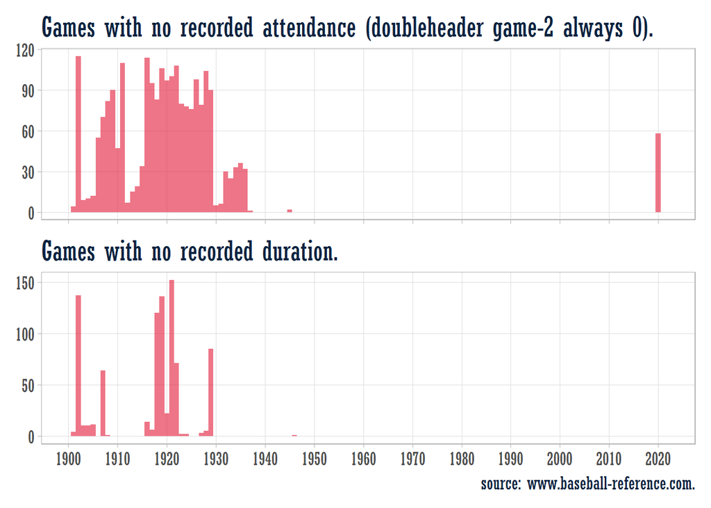

Curious about the attendance data. Do the peaks and troughs correlate with the team’s success? The answer is usually “yes”, except for 1954. The Tribe won 111 games that year, but drew only around 20,000 per game, a 50% drop from their 1948 pennant-winning season. In a way, it was the 1948-49 seasons that were anomalous. The Tribe had never seen crowds like that before, and wouldn’t again until 1995.

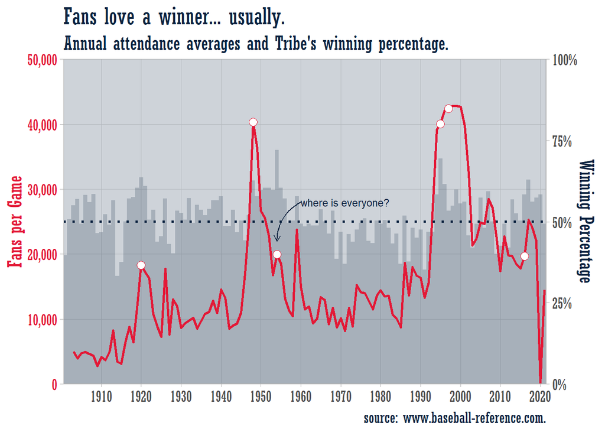

As an aside, check out 1917 and 1918. Game attendance does not seem unusual those two years despite WWI and the influenza pandemic. The US entered WWI in Apr ’17 and the war ended after the season concluded in ’18. The 1918 influenza pandemic started in the spring, but seems to have really taken off around October. Baseball survived the war as an acceptable diversion from civic duty, and in fact patriotic elements were integrated into the games.

Doubleheaders were common through the mid-1960s. Let’s take a closer look. Over 50% of baseball games in 1943 were played as part of a doubleheader. Doubleheaders have been relatively rare since the 1980s.

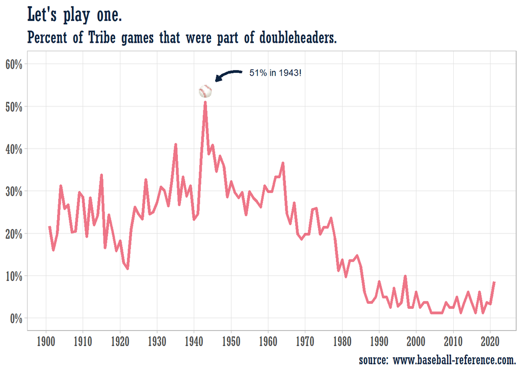

As with the attendance data, game duration data is also frequently unavailable prior to 1930.

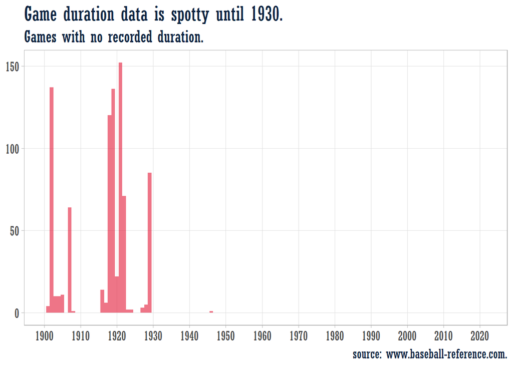

## Game Duration

If it seems like Tribe games are taking longer to complete, you are right. The annual average game duration has been increasing since 2003. Prior to 2003, it had briefly fallen from an all-time high of 3 hours 9 minutes in 2000. Early in the 1900s, games took a little over an hour and a half, but were increasing and by 1920 game times had climbed over two hours. From 1921 to 1945 game times were steady at about two hours, but began to climb again after WWII, reaching two and half hours by 1955. Game times stabilized at 2.5 hours from 1955 to 1975, before rising again. The average Tribe game time in 2021 was 3 hours 5 minutes.

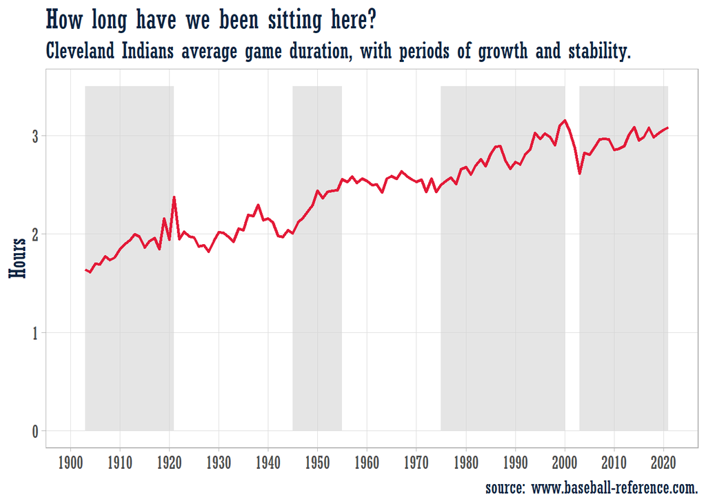

Doubleheaders have become less common while game times have increased. Is there a negative correlation, perhaps a compensating effect? Let’s print the same chart, but control for whether the game is part of a doubleheader. The answer is no, doubleheaders are irrelevant. The average doubleheader game is shorter by all of 2 minutes.

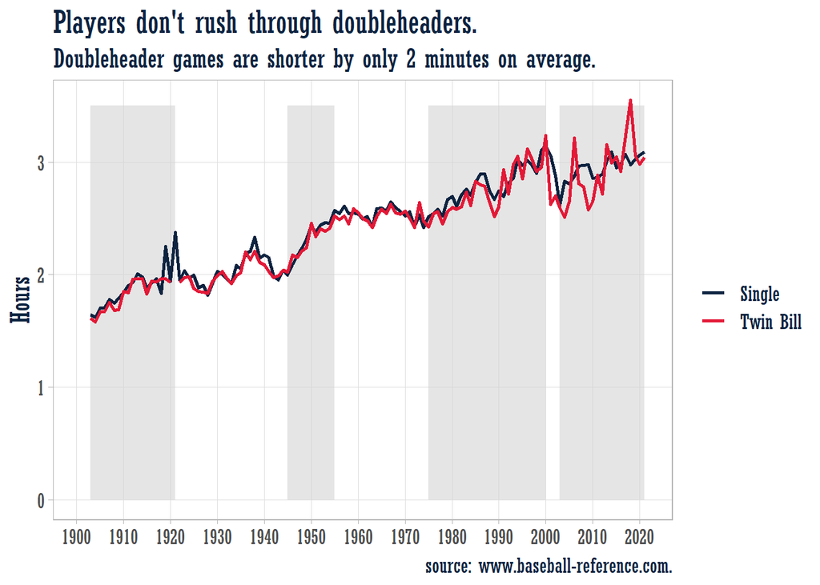

How about day games? Until the late 1930s, all games were played in the afternoon. By the mid 1970s day games were primarily on weekends. While there might be a different dynamic to paying in the afternoon (*it’s hot - let’s get out of here!*), the data doesn’t bear that out. The advent of night games is not associated with longer games.

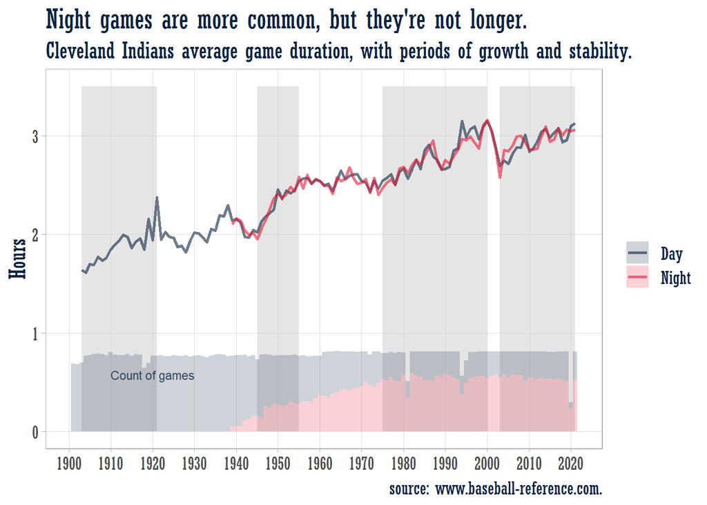

I’m curious about the dip in game duration between 2000 and 2003. Game duration reached its peak at 3:09 per game in 2000. Then it underwent a brief period of decline, falling to 2:37 in 2003. It climbed back to 3:05 in 2021. I wonder if the reduction in offense after the steroid era is related. Below is the trend of average game times with total runs scored. They both plummeted over that three year period, but they’ve been moving in opposite directions since 2010.

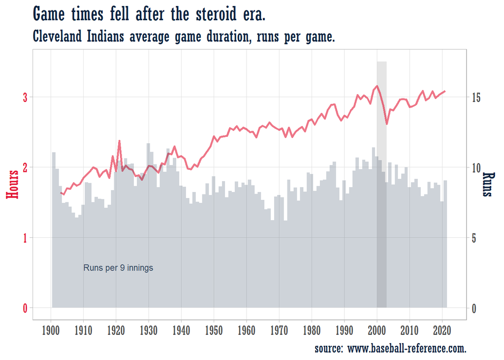

Incidentally, compare the offense in the 1930s to the steroid era of the 1990s. And there’s that year of the pitcher, 1968. But then 1972 does not look so hot. It should be noted that these are just Cleveland Indians games. There may be seasons when the Tribe had decent pitching, but no hitting, or vice-versa (or, sadly, neither).

## Duration Trends

Average game duration does not appear to change much within seasons - it looks like it falls about .2 hours (12 minutes) over the course of the season. The apparent increase in March game times is an artifact of March games not occurring until 1998.

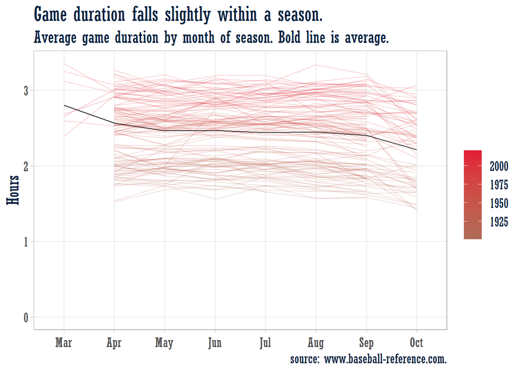

## Benchmark Forecasts

- The **average method** projects the historical average, $\hat{y}_{T+h|T} = \bar{y}.$
- The **naive method** projects the last observation, $\hat{y}_{T+h|T} = y_T.$
- The **seasonal naive method** projects the last seasonal observation, $\hat{y}_{T+h|T} = y_{T+h-m(k+1)}$.

The methods can include drift, a straight line from the first and last observation, $\hat{y}_{T+h|T} = y_T + h\left(\frac{y_T - y_1}{T-1}\right).$

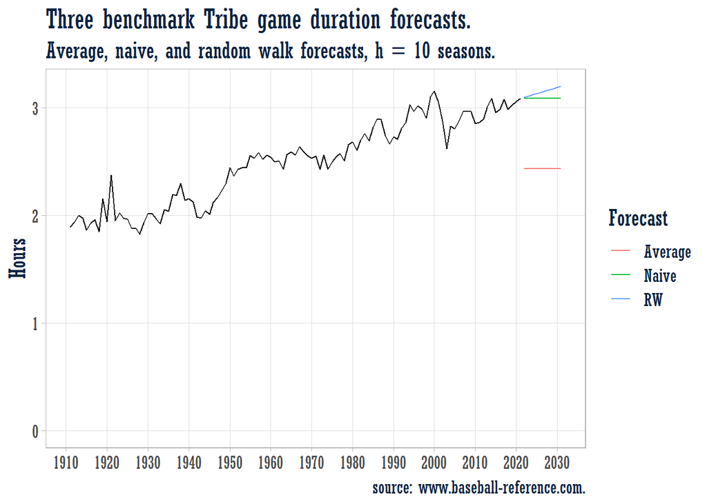